# Organic Matter Supply Model: Assessing model performance using simulated data from Station ALOHA - excluding threonine

# 5 Model Assessment

Now let’s gather up posteriors from the OMSM and plot those relative to the tue values we used to simulate the data to get an idea for how the model is performing.

```r
OMSM_Extract_Posts(
  rjo_1 = rjo_1,
  Data.zoops = Data.zoops,
  Sources,
  Variables,
  Tracers
)
```

## Source tracer values

First we’ll generate some plots of the mean source tracer value posteriors ($\mu_{j,i}$) relative to the original source data.

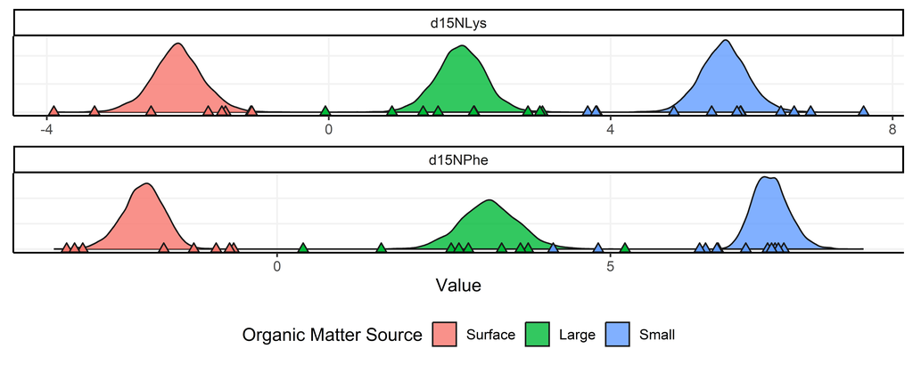

```r
plot_sourcepost_sim(posts.long, Data.sources, Tracers)
```

## Basal tracer values

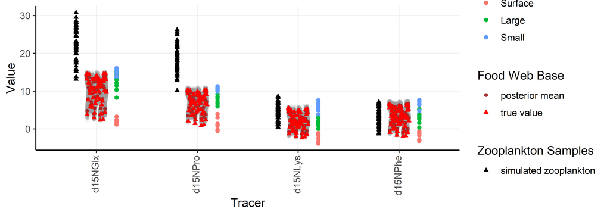

```r
plot_basepost_sim(posts, posts.long, Data.sources, Data.zoops, base.sim, Tracers, Variables, LDA.full)
```

## Consumer tracer values

We also want to look at the mean_z parameter for each zooplankton sample to see if and where the posteriors for mixing tracers are deviating from the data. If they are, that means either the TDFs are not accurate or there is a missing organic mater source.

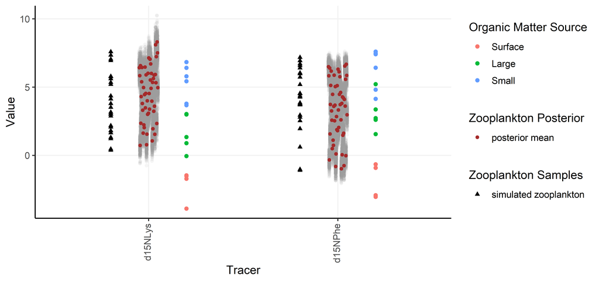

```r
plot_zooppost_sim(
  posts.long,
  Data.zoops,
  Data.sources,
  base.sim,
  Tracers
)
```

## Trophic parameters

We also want to plot comparisons of the trophic parameters used to simulate the zooplankton data and the model posteriors for those parameters. Posterior HDIs (95%, 90%, 75%, and 50%) are shown in blue bars, with posterior modes indicated with text. True values are indicated by yellow lines. Righthand plots show relationships between true and modeled values, with discrepancy plots showing the difference between modeled and true values.

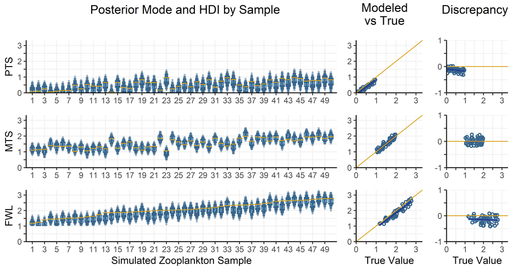

```r
plot<-
plotall_trophicpost_sim(posts, zoops.f)
   Warning: Using `size` aesthetic for lines was deprecated in ggplot2 3.4.0.
   ℹ Please use `linewidth` instead.
   This warning is displayed once every 8 hours.
   Call `lifecycle::last_lifecycle_warnings()` to see where this warning was
   generated.
   No id variables; using all as measure variables
   No id variables; using all as measure variables
plot
```

We’ll briefly quantify model error as well by looking at the discrepancy between modeled and true trophic parameter values. Expand the code chunk to see the mean and maximum error rates for each parameter.

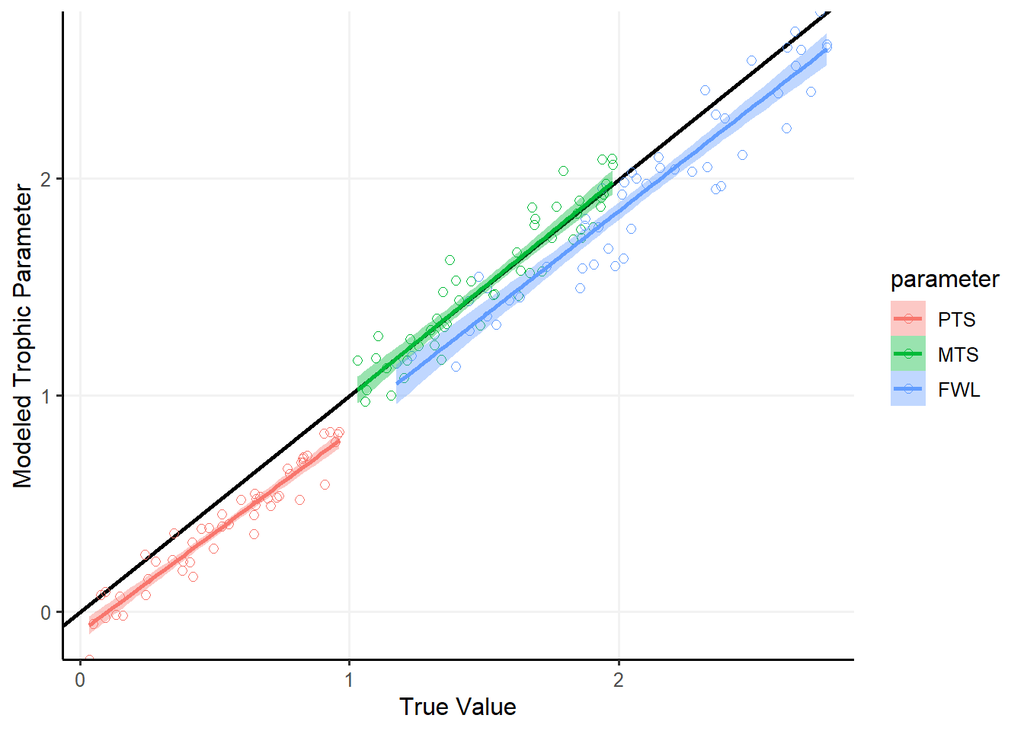

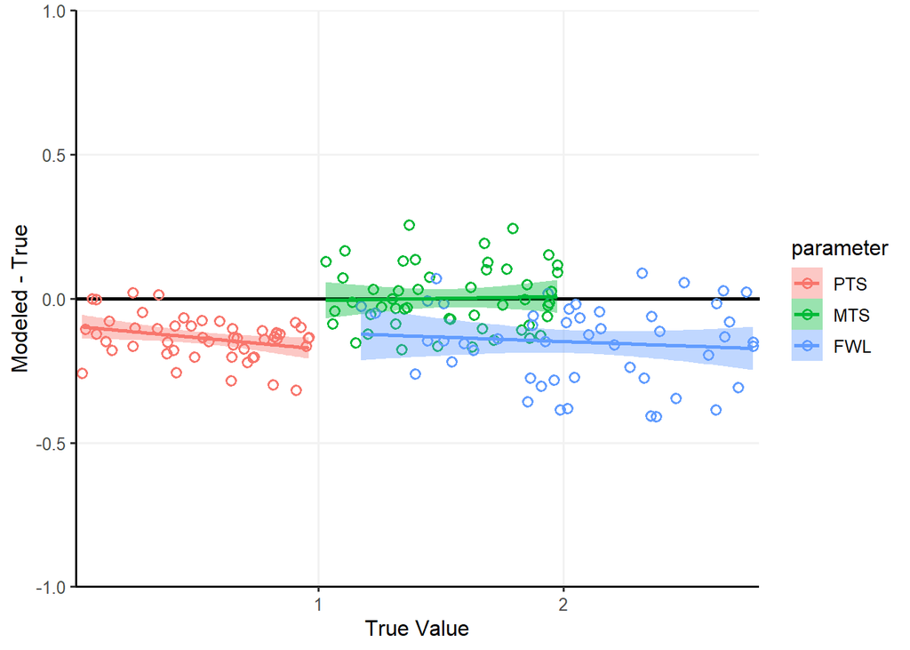

```r
Post_Error_Quant_Trophic(
  zoops.f,
  posts
)
   [1] "Mean error rates associated with each trohic parameter:"
          PTS        MTS        FWL
   0.13919392 0.09053542 0.16223810
   [1] "maximum error - PTS"
   [1] 0.3187045
   [1] "maximum error - MTS"
   [1] 0.2554363
   [1] "maximum error - FWL"
   [1] 0.4092299

plot_Post_Error_Trophic(
  zoops.f,
  posts
)
   No id variables; using all as measure variables
   No id variables; using all as measure variables
   [[1]]
```

## Mixing coefficients

Last we’ll do the same for mixing coefficients.

```r
height = length(Sources)*1.5
```

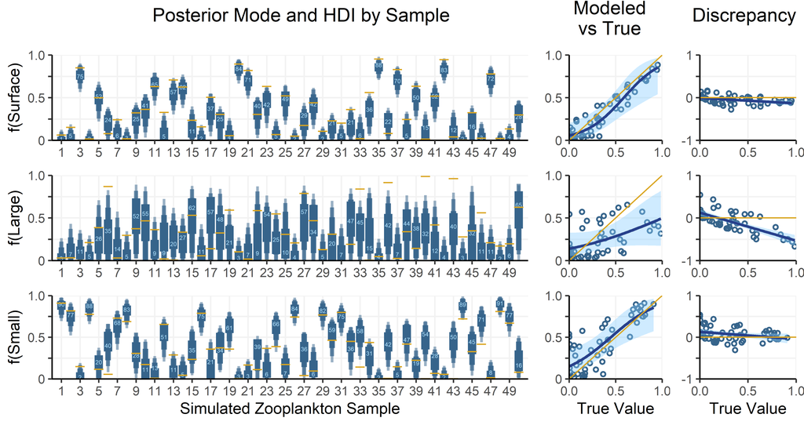

```r
plot <- plotall_fpost_sim(posts, zoops.f, Sources)
   Warning: `aes_string()` was deprecated in ggplot2 3.0.0.
   ℹ Please use tidy evaluation idioms with `aes()`.
   ℹ See also `vignette("ggplot2-in-packages")` for more information.
   This warning is displayed once every 8 hours.
   Call `lifecycle::last_lifecycle_warnings()` to see where this warning was
   generated.
   No id variables; using all as measure variables
   No id variables; using all as measure variables
   Warning in eval(family$initialize): non-integer #successes in a binomial glm!
   Warning in eval(family$initialize): non-integer #successes in a binomial glm!
   Warning in eval(family$initialize): non-integer #successes in a binomial glm!
   Warning in eval(family$initialize): non-integer #successes in a binomial glm!
   Warning in eval(family$initialize): non-integer #successes in a binomial glm!
   Warning in eval(family$initialize): non-integer #successes in a binomial glm!
plot
```

We’ll also quantify model accuracy for mixing coefficients. Expand the code chunk to see the mean and maximum error rates for each source.

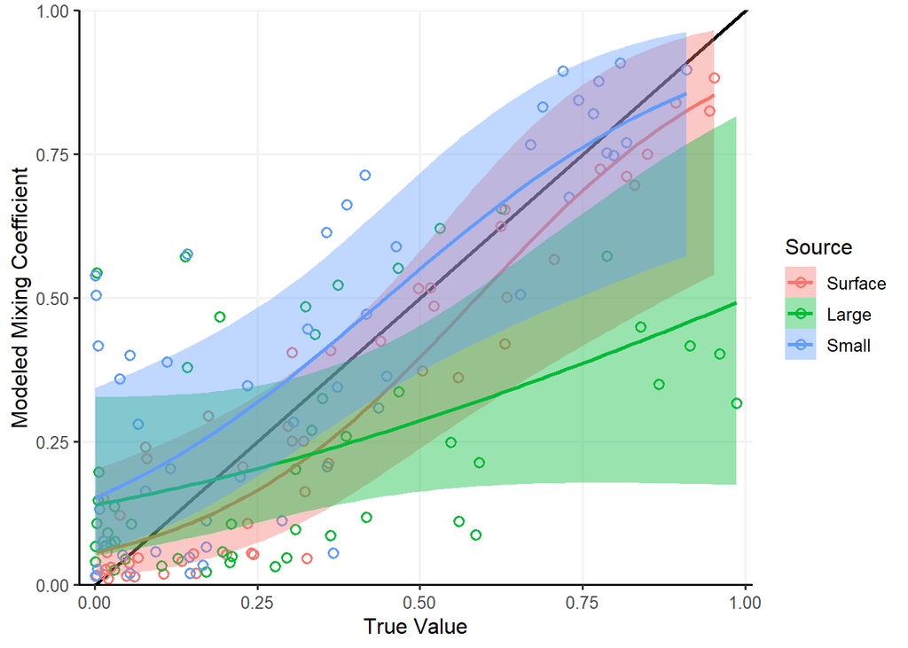

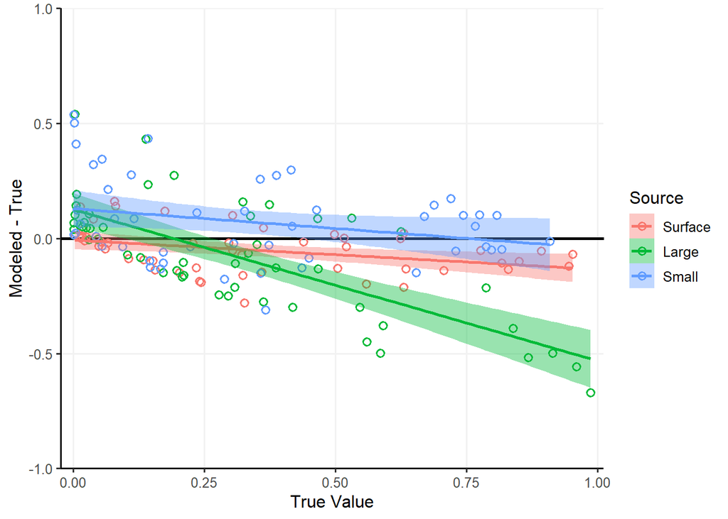

```r
Post_Error_Quant_f(
    zoops.f,
    posts
)
   [1] "Mean error rates associated with each mixing parameter:"
      Surface      Large      Small
   0.08680924 0.20202707 0.14679025
   [1] "maximum error - Surface particles:"
   [1] 0.2795733
   [1] "maximum error - Large particles:"
   [1] 0.6698853
   [1] "maximum error - Small particles:"
   [1] 0.537626

plot_Post_Error_f(
    zoops.f,
    posts,
    Sources
)
   No id variables; using all as measure variables
   No id variables; using all as measure variables
   [[1]]
```

# Exporting results

The last thing we want to do here is export out mixing model results to a .RData file. Load this file into other R scripts to do additional analyses.

```r
save(posts,
     posts.long,
     Data.all,
     zoops.sim,
     file = paste0("Data/",export.file.name))
```

# Comparing to model results including Thr

Now we’d like to build a couple simple plots illustrating how including/excluding a trophic AA like Thr impact our ability to accurately solve the mixing problem.

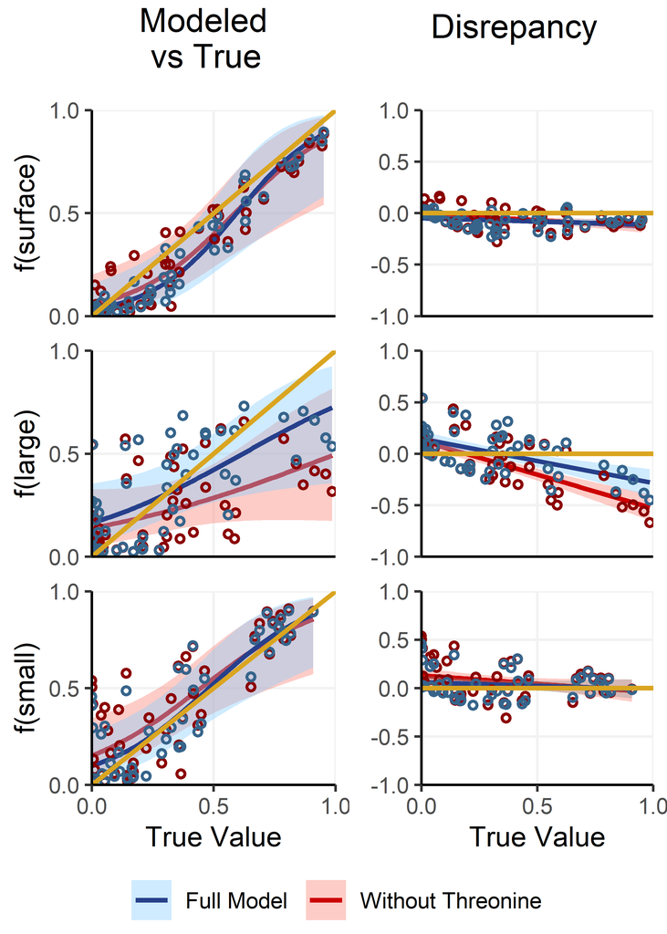

```r
data.true <- zoops.f[Sources]
data.model <- posts$f$mode[Sources]
# data.model$Model <- "OMSM - no Thr"
# data.model$Model <- factor(data.model$Model, levels = c("OMSM - full","OMSM - no Thr"))


mix.disc <- data.model-data.true
mix.disc$Model <- "OMSM - no Thr"
mix.disc$Model <- factor(mix.disc$Model, levels = c("OMSM - full","OMSM - no Thr"))

data.model.long <-
  melt(data.model[Sources],
       value.name = "f_model",
       variable.name = "Source"
  )
   No id variables; using all as measure variables
data.true.long <-
  melt(data.true[Sources],
       value.name = "f_true",
       variable.name = "Source"
  )
   No id variables; using all as measure variables
data.truemod.long <-
  cbind(
    data.true.long,
    data.model.long["f_model"]
  )
data.truemod.long$f_disc <-
  data.truemod.long$f_model -
  data.truemod.long$f_true



load("Data/ALOHAsim_OMSM_posteriors.RData")
posts.OMSM2 <- posts
posts.OMSM2.long <- posts.long

data.true <- zoops.f[c("Surface","Large","Small")]
data.model.full <-
  cbind(
    posts.OMSM2$f$mode[c("Surface","Large","Small")]
  )

mix.disc.full <- data.model.full-data.true
mix.disc.full$Model <- "OMSM - no Thr" # posts.mode$Model
mix.disc.full$Model <- factor(mix.disc.full$Model, levels = c("OMSM - full","OMSM - no Thr"))



data.model.full.long <-
  melt(data.model.full[Sources],
       value.name = "f_model",
       variable.name = "Source"
  )
   No id variables; using all as measure variables
data.true.long <-
  melt(data.true[Sources],
       value.name = "f_true",
       variable.name = "Source"
  )
   No id variables; using all as measure variables
data.truemod.full.long <-
  cbind(
    data.true.long,
    data.model.full.long["f_model"]
  )
data.truemod.full.long$f_disc <-
  data.truemod.full.long$f_model -
  data.truemod.long$f_true


plot.TM.surf <-
  ggplot()+
  geom_smooth(data = subset(data.truemod.long, Source == "Surface"),
    aes(x = f_true, y = f_model, color = "Without Threonine"),
        fill = "salmon",
    # method = "lm"
    method = "glm", method.args = list(family = binomial())
  )+
  geom_smooth(data = subset(data.truemod.full.long, Source == "Surface"),
    aes(x = f_true, y = f_model, color = "Full Model"),
        fill = "skyblue1",
    # method = "lm"
    method = "glm", method.args = list(family = binomial())
  )+
  geom_point(data = subset(data.truemod.long, Source == "Surface"),
    aes(x = f_true, y = f_model),
    size = 1, stroke=1, shape = 1, color = "red4"
  )+
  geom_point(data = subset(data.truemod.full.long, Source == "Surface"),
    aes(x = f_true, y = f_model),
    size = 1, stroke=1, shape = 1, color = "steelblue4"
  )+
  scale_color_manual(values = c("royalblue4","red3"))+
  labs(color = "")+
  geom_abline(slope = 1, intercept = 0, size = 1, color = "goldenrod")+
  coord_cartesian(ylim = c(0,1), xlim = c(0,1), expand = FALSE)+
  scale_x_continuous(breaks = c(0,0.5,1))+
  scale_y_continuous(breaks = c(0,0.5,1))
# plot.TM.surf

plot.TM.large <-
  ggplot()+
  geom_smooth(data = subset(data.truemod.long, Source == "Large"),
    aes(x = f_true, y = f_model, color = "Without Threonine"),
        fill = "salmon",
    # method = "lm"
    method = "glm", method.args = list(family = binomial())
  )+
  geom_smooth(data = subset(data.truemod.full.long, Source == "Large"),
    aes(x = f_true, y = f_model, color = "Full Model"),
        fill = "skyblue1",
    # method = "lm"
    method = "glm", method.args = list(family = binomial())
  )+
  geom_point(data = subset(data.truemod.long, Source == "Large"),
    aes(x = f_true, y = f_model),
    size = 1, stroke=1, shape = 1, color = "red4"
  )+
  geom_point(data = subset(data.truemod.full.long, Source == "Large"),
    aes(x = f_true, y = f_model),
    size = 1, stroke=1, shape = 1, color = "steelblue4"
  )+
  scale_color_manual(values = c("royalblue4","red3"))+
  labs(color = "")+
  geom_abline(slope = 1, intercept = 0, size = 1, color = "goldenrod")+
  coord_cartesian(ylim = c(0,1), xlim = c(0,1), expand = FALSE)+
  scale_x_continuous(breaks = c(0,0.5,1))+
  scale_y_continuous(breaks = c(0,0.5,1))
# plot.TM.large

plot.TM.small <-
  ggplot()+
  geom_smooth(data = subset(data.truemod.long, Source == "Small"),
    aes(x = f_true, y = f_model, color = "Without Threonine"),
        fill = "salmon",
    # method = "lm"
    method = "glm", method.args = list(family = binomial())
  )+
  geom_smooth(data = subset(data.truemod.full.long, Source == "Small"),
    aes(x = f_true, y = f_model, color = "Full Model"),
        fill = "skyblue1",
    # method = "lm"
    method = "glm", method.args = list(family = binomial())
  )+
  geom_point(data = subset(data.truemod.long, Source == "Small"),
    aes(x = f_true, y = f_model),
    size = 1, stroke=1, shape = 1, color = "red4"
  )+
  geom_point(data = subset(data.truemod.full.long, Source == "Small"),
    aes(x = f_true, y = f_model),
    size = 1, stroke=1, shape = 1, color = "steelblue4"
  )+
  scale_color_manual(values = c("royalblue4","red3"))+
  labs(color = "")+
  geom_abline(slope = 1, intercept = 0, size = 1, color = "goldenrod")+
  coord_cartesian(ylim = c(0,1), xlim = c(0,1), expand = FALSE)+
  scale_x_continuous(breaks = c(0,0.5,1))+
  scale_y_continuous(breaks = c(0,0.5,1))
# plot.TM.small

plot.disc.surf <-
  ggplot()+
  geom_smooth(data = subset(data.truemod.long, Source == "Surface"),
    aes(x = f_true, y = f_disc, color = "Without Threonine"),
        fill = "salmon",
    method = "lm"
    # method = "glm", method.args = list(family = binomial())
  )+
  geom_smooth(data = subset(data.truemod.full.long, Source == "Surface"),
    aes(x = f_true, y = f_disc, color = "Full Model"),
        fill = "skyblue1",
    method = "lm"
    # method = "glm", method.args = list(family = binomial())
  )+
  geom_point(data = subset(data.truemod.long, Source == "Surface"),
    aes(x = f_true, y = f_disc),
    size = 1, stroke=1, shape = 1, color = "red4"
  )+
  geom_point(data = subset(data.truemod.full.long, Source == "Surface"),
    aes(x = f_true, y = f_disc),
    size = 1, stroke=1, shape = 1, color = "steelblue4"
  )+
  scale_color_manual(values = c("royalblue4","red3"))+
  labs(color = "")+
  geom_abline(slope = 0, intercept = 0, size = 1, color = "goldenrod")+
  coord_cartesian(ylim = c(-1,1), xlim = c(0,1), expand = FALSE)+
  scale_x_continuous(breaks = c(-1,-0.5,0,0.5,1))+
  scale_y_continuous(breaks = c(-1,-0.5,0,0.5,1))
# plot.disc.surf

plot.disc.large <-
  ggplot()+
  geom_smooth(data = subset(data.truemod.long, Source == "Large"),
    aes(x = f_true, y = f_disc, color = "Without Threonine"),
        fill = "salmon",
    method = "lm"
    # method = "glm", method.args = list(family = binomial())
  )+
  geom_smooth(data = subset(data.truemod.full.long, Source == "Large"),
    aes(x = f_true, y = f_disc, color = "Full Model"),
        fill = "skyblue1",
    method = "lm"
    # method = "glm", method.args = list(family = binomial())
  )+
  geom_point(data = subset(data.truemod.long, Source == "Large"),
    aes(x = f_true, y = f_disc),
    size = 1, stroke=1, shape = 1, color = "red4"
  )+
  geom_point(data = subset(data.truemod.full.long, Source == "Large"),
    aes(x = f_true, y = f_disc),
    size = 1, stroke=1, shape = 1, color = "steelblue4"
  )+
  scale_color_manual(values = c("royalblue4","red3"))+
  labs(color = "")+
  geom_abline(slope = 0, intercept = 0, size = 1, color = "goldenrod")+
  coord_cartesian(ylim = c(-1,1), xlim = c(0,1), expand = FALSE)+
  scale_x_continuous(breaks = c(-1,-0.5,0,0.5,1))+
  scale_y_continuous(breaks = c(-1,-0.5,0,0.5,1))
# plot.disc.large

plot.disc.small <-
  ggplot()+
  geom_smooth(data = subset(data.truemod.long, Source == "Small"),
    aes(x = f_true, y = f_disc, color = "Without Threonine"),
        fill = "salmon",
    method = "lm"
    # method = "glm", method.args = list(family = binomial())
  )+
  geom_smooth(data = subset(data.truemod.full.long, Source == "Small"),
    aes(x = f_true, y = f_disc, color = "Full Model"),
        cfill = "skyblue1",
    method = "lm"
    # method = "glm", method.args = list(family = binomial())
  )+
  geom_point(data = subset(data.truemod.long, Source == "Small"),
    aes(x = f_true, y = f_disc),
    size = 1, stroke=1, shape = 1, color = "red4"
  )+
  geom_point(data = subset(data.truemod.full.long, Source == "Small"),
    aes(x = f_true, y = f_disc),
    size = 1, stroke=1, shape = 1, color = "steelblue4"
  )+
  scale_color_manual(values = c("royalblue4","red3"))+
  labs(color = "")+
  geom_abline(slope = 0, intercept = 0, size = 1, color = "goldenrod")+
  coord_cartesian(ylim = c(-1,1), xlim = c(0,1), expand = FALSE)+
  scale_x_continuous(breaks = c(-1,-0.5,0,0.5,1))+
  scale_y_continuous(breaks = c(-1,-0.5,0,0.5,1))
   Warning in geom_smooth(data = subset(data.truemod.full.long, Source ==
   "Small"), : Ignoring unknown parameters: `cfill`
# plot.disc.small


ggarrange(
  ggplot() + geom_blank() + ggtitle("Modeled\nvs True") +
    theme(plot.title = element_text(hjust = 0.65)),
  ggplot() + geom_blank() + ggtitle("Disrepancy") +
    theme(plot.title = element_text(hjust = 0.55)),

  plot.TM.surf + no.x.axis + ylab("f(surface)"),
  plot.disc.surf + no.x.axis +
    theme(axis.title.y = element_blank()),

  plot.TM.large + no.x.axis + ylab("f(large)"),
  plot.disc.large + no.x.axis +
    theme(axis.title.y = element_blank()),

  plot.TM.small + ylab("f(small)") + xlab("True Value"),
  plot.disc.small + xlab("True Value") +
    theme(axis.title.y = element_blank()),

  ncol = 2, nrow = 4,
  heights = c(0.4,1,1,1.2),
  widths = c(1.1,1),
  common.legend = TRUE,
  legend = "bottom"
)
   `geom_smooth()` using formula = 'y ~ x'
   Warning in eval(family$initialize): non-integer #successes in a binomial glm!
   `geom_smooth()` using formula = 'y ~ x'
   Warning in eval(family$initialize): non-integer #successes in a binomial glm!
   `geom_smooth()` using formula = 'y ~ x'
   Warning in eval(family$initialize): non-integer #successes in a binomial glm!
   `geom_smooth()` using formula = 'y ~ x'
   Warning in eval(family$initialize): non-integer #successes in a binomial glm!
   `geom_smooth()` using formula = 'y ~ x'
   `geom_smooth()` using formula = 'y ~ x'
   `geom_smooth()` using formula = 'y ~ x'
   Warning in eval(family$initialize): non-integer #successes in a binomial glm!
   `geom_smooth()` using formula = 'y ~ x'
   Warning in eval(family$initialize): non-integer #successes in a binomial glm!
   `geom_smooth()` using formula = 'y ~ x'
   `geom_smooth()` using formula = 'y ~ x'
   `geom_smooth()` using formula = 'y ~ x'
   Warning in eval(family$initialize): non-integer #successes in a binomial glm!
   `geom_smooth()` using formula = 'y ~ x'
   Warning in eval(family$initialize): non-integer #successes in a binomial glm!
   `geom_smooth()` using formula = 'y ~ x'
   `geom_smooth()` using formula = 'y ~ x'
```